# Data Science Tutorial

By River Pearson

Made for José Calderon's Spring 2021 CMSC320 class.

## Introduction

Welcome to the data science pipeline tutorial. This tutorial is designed to walk newcomers through the data science process of data collection/curation and parsing, data management/representation, exploratory analysis, and hypothesis testing/machine learning, as well as effective communication of insights attained.

To do this, we will utilize the IMDb datasets publicly available on their website. These datasets contain information about the works documented and ranked on https://www.imdb.com/. We will use them to explore popular movies (defined in this tutorial as movies with over 100,000 ranking votes) and their evolution over time, with the purpose of demonstrating the importance of context when doing data science.

## Setup

First, we need to import necessary packages. These include pandas (a data manipulation and analysis package), numpy (a numerical and mathematics package), and pyplot (a graphing package).

```python
import pandas as pd
import numpy as np
import matplotlib.pyplot as plt
```

## Loading the Data

Next, we will use pandas to read in the datasets, currently represented as CSVs, into DataFrames, a data storage object type. The first one we are reading is the basics dataset, which contains general information about each of the documented works.

```python
df = pd.read_csv("title.basics.tsv.gz",sep='\t',low_memory=False)
df.head()
```

|  | tconst | titleType | primaryTitle | originalTitle | isAdult | startYear | endYear | runtimeMinutes | genres |
| --- | --- | --- | --- | --- | --- | --- | --- | --- | --- |
| 0 | tt0000001 | short | Carmencita | Carmencita | 0 | 1894 | \N | 1 | Documentary,Short |
| 1 | tt0000002 | short | Le clown et ses chiens | Le clown et ses chiens | 0 | 1892 | \N | 5 | Animation,Short |
| 2 | tt0000003 | short | Pauvre Pierrot | Pauvre Pierrot | 0 | 1892 | \N | 4 | Animation,Comedy,Romance |
| 3 | tt0000004 | short | Un bon bock | Un bon bock | 0 | 1892 | \N | 12 | Animation,Short |
| 4 | tt0000005 | short | Blacksmith Scene | Blacksmith Scene | 0 | 1893 | \N | 1 | Comedy,Short |

Next we will read in the ratings dataset, which contains user rankings for some of the works as well as the number of votes.

```python
df2 = pd.read_csv("title.ratings.tsv.gz",sep='\t',low_memory=False)
df2.head()
```

|  | tconst | averageRating | numVotes |
| --- | --- | --- | --- |
| 0 | tt0000001 | 5.7 | 1723 |
| 1 | tt0000002 | 6.0 | 211 |
| 2 | tt0000003 | 6.5 | 1485 |
| 3 | tt0000004 | 6.1 | 124 |
| 4 | tt0000005 | 6.2 | 2286 |

## Tidying and Parsing the Data

These datasets do not contain the same number of works, as demonstrated in the cell below:

```python
print(df.shape[0])
print(df2.shape[0])
```

```
8093043
1172312
```

To resolve this, we need to merge the databases. This merge function takes multiple dataframes and combines them into a single dataframe. The function defaults to an "inner" join, meaning the function will toss out any row that does not have an equivalent in the other database. In this case, that merge condition is defined by the first column, tconst, which has a unique numeric identifier for each of the works. In this way, we are able to keep only the rows that have been ranked and that have general information available.

```python
# cdf = Complete DataFrame
cdf = pd.merge(df, df2)
print(cdf.shape[0])
cdf.head()
```

```
1172308
```

|  | tconst | titleType | primaryTitle | originalTitle | isAdult | startYear | endYear | runtimeMinutes | genres | averageRating | numVotes |
| --- | --- | --- | --- | --- | --- | --- | --- | --- | --- | --- | --- |
| 0 | tt0000001 | short | Carmencita | Carmencita | 0 | 1894 | \N | 1 | Documentary,Short | 5.7 | 1723 |
| 1 | tt0000002 | short | Le clown et ses chiens | Le clown et ses chiens | 0 | 1892 | \N | 5 | Animation,Short | 6.0 | 211 |
| 2 | tt0000003 | short | Pauvre Pierrot | Pauvre Pierrot | 0 | 1892 | \N | 4 | Animation,Comedy,Romance | 6.5 | 1485 |
| 3 | tt0000004 | short | Un bon bock | Un bon bock | 0 | 1892 | \N | 12 | Animation,Short | 6.1 | 124 |
| 4 | tt0000005 | short | Blacksmith Scene | Blacksmith Scene | 0 | 1893 | \N | 1 | Comedy,Short | 6.2 | 2286 |

Additionally, this dataframe currently contains over a million different entries, most of which are television series episodes. To make this number a tad bit more reasonable for our CPU, we will be strictly be looking at movies. We will also eliminate adult movies and drop some of the irrelevant columns, namely the now-defunct isAdult and titleType variables, as well as endYear, which only had a relevant value if the work belonged to an ongoing series that did not conclude the same year it was started.

```python
cdf = cdf[cdf["titleType"]=="movie"]
cdf = cdf[cdf["isAdult"]=="0"]
cdf = cdf.drop(['titleType', 'isAdult', 'endYear'], axis = 1)
print(cdf.shape[0])
cdf.head()
```

```
261647
```

|  | tconst | primaryTitle | originalTitle | startYear | runtimeMinutes | genres | averageRating | numVotes |
| --- | --- | --- | --- | --- | --- | --- | --- | --- |
| 340 | tt0000502 | Bohemios | Bohemios | 1905 | 100 | \N | 4.5 | 8 |
| 374 | tt0000574 | The Story of the Kelly Gang | The Story of the Kelly Gang | 1906 | 70 | Action,Adventure,Biography | 6.1 | 643 |
| 383 | tt0000591 | The Prodigal Son | L'enfant prodigue | 1907 | 90 | Drama | 5.2 | 6 |
| 398 | tt0000615 | Robbery Under Arms | Robbery Under Arms | 1907 | \N | Drama | 4.5 | 14 |
| 406 | tt0000630 | Hamlet | Amleto | 1908 | \N | Drama | 3.8 | 12 |

## Missing Data

Sometimes, data goes missing. This could be from a variety of things: human error, errors in getting the data, bad formatting, etc. In any case, we must screen for any missing values. Fortunately, dataframes let us do this fairly easily if we go column by column. Most would first attempt something akin to below, attempting to use the isna function to check if something is NaN:

```python
cdf = cdf[pd.isna(cdf["primaryTitle"]) != True]
cdf = cdf[pd.isna(cdf["originalTitle"]) != True]
cdf = cdf[pd.isna(cdf["startYear"]) != True]
cdf = cdf[pd.isna(cdf["runtimeMinutes"]) != True]
cdf = cdf[pd.isna(cdf["genres"]) != True]
cdf = cdf[pd.isna(cdf["averageRating"]) != True]
cdf = cdf[pd.isna(cdf["numVotes"]) != True]
print(cdf.shape[0])
cdf.head()
```

```
261647
```

|  | tconst | primaryTitle | originalTitle | startYear | runtimeMinutes | genres | averageRating | numVotes |
| --- | --- | --- | --- | --- | --- | --- | --- | --- |
| 340 | tt0000502 | Bohemios | Bohemios | 1905 | 100 | \N | 4.5 | 8 |
| 374 | tt0000574 | The Story of the Kelly Gang | The Story of the Kelly Gang | 1906 | 70 | Action,Adventure,Biography | 6.1 | 643 |
| 383 | tt0000591 | The Prodigal Son | L'enfant prodigue | 1907 | 90 | Drama | 5.2 | 6 |
| 398 | tt0000615 | Robbery Under Arms | Robbery Under Arms | 1907 | \N | Drama | 4.5 | 14 |
| 406 | tt0000630 | Hamlet | Amleto | 1908 | \N | Drama | 3.8 | 12 |

However, we can see from the shape function that this isn't actually eliminating data. The isna function does not work on strings, of which all of the columns are currently, even the purely numeric ones. This could be resolved by recasting each of the numeric columns as numbers; however, doing so would not resolve missing values in non-numeric columns. Rather, if we look at the data itself, we can see that the missing values seem to be encoded by "\N". Let's try that filtering again:

```python
cdf = cdf[cdf["primaryTitle"] != "\\N"]
cdf = cdf[cdf["originalTitle"] != "\\N"]
cdf = cdf[cdf["startYear"] != "\\N"]
cdf = cdf[cdf["runtimeMinutes"] != "\\N"]
cdf = cdf[cdf["genres"] != "\\N"]
cdf = cdf[cdf["averageRating"] != "\\N"]
cdf = cdf[cdf["numVotes"] != "\\N"]
print(cdf.shape[0])
cdf.head()
```

```
229663
```

|  | tconst | primaryTitle | originalTitle | startYear | runtimeMinutes | genres | averageRating | numVotes |
| --- | --- | --- | --- | --- | --- | --- | --- | --- |
| 374 | tt0000574 | The Story of the Kelly Gang | The Story of the Kelly Gang | 1906 | 70 | Action,Adventure,Biography | 6.1 | 643 |
| 383 | tt0000591 | The Prodigal Son | L'enfant prodigue | 1907 | 90 | Drama | 5.2 | 6 |
| 439 | tt0000679 | The Fairylogue and Radio-Plays | The Fairylogue and Radio-Plays | 1908 | 120 | Adventure,Fantasy | 5.3 | 36 |
| 733 | tt0001184 | Don Juan de Serrallonga | Don Juan de Serrallonga | 1910 | 58 | Adventure,Drama | 3.4 | 11 |
| 762 | tt0001258 | The White Slave Trade | Den hvide slavehandel | 1910 | 45 | Drama | 5.7 | 107 |

Now that did something this time; over 30,000 entries ended up containing missing data. This is why it is important to screen for missing data, but also to make sure to examine how the data is being represented.

Now that we've screened for missing data, we want to work the data into a more useful format. This ties back into the tidying/parsing step; backtracking is common when doing data science, so this is nothing to worry about. Due to the size of the database and my hardware limitations, I am only going to focus on the entries that have been rated by a substantial set of the population. Many of the entries in the database have only been rated by a number of people too small of a sample to be considered accurate, and as a result we will place a limitation on the database of numVotes needing to be higher than 100000.

```python
cdf = cdf[cdf["numVotes"]>=100000]
cdf.sort_values(by=["averageRating"], inplace=True, ascending=False)
print(cdf.shape[0])
cdf.head()
```

```
1991
```

|  | tconst | primaryTitle | originalTitle | startYear | runtimeMinutes | genres | averageRating | numVotes |
| --- | --- | --- | --- | --- | --- | --- | --- | --- |
| 82082 | tt0111161 | The Shawshank Redemption | The Shawshank Redemption | 1994 | 142 | Drama | 9.3 | 2419048 |
| 45881 | tt0068646 | The Godfather | The Godfather | 1972 | 175 | Crime,Drama | 9.2 | 1673008 |
| 248330 | tt0468569 | The Dark Knight | The Dark Knight | 2008 | 152 | Action,Crime,Drama | 9.0 | 2376417 |
| 29784 | tt0050083 | 12 Angry Men | 12 Angry Men | 1957 | 96 | Crime,Drama | 9.0 | 712688 |
| 48414 | tt0071562 | The Godfather: Part II | The Godfather: Part II | 1974 | 202 | Crime,Drama | 9.0 | 1161904 |

With this singular limitation we've reduced the size of the database by a hundredfold. This gives us a much more workable database given my personal hardware.

Finally, we will rework some of the columns into more useful formats. The genre tags are currently represented as singular strings. In order to make them workable, we will convert these strings into a list of genres. Additionally, we will cast the numeric rows from strings into integers or floats.

```python
temp = []
for i, r in cdf.iterrows():
    temp.append(r["genres"].split(","))
cdf["genres"] = temp
cdf["startYear"] = cdf["startYear"].astype(int)
cdf["runtimeMinutes"] = cdf["runtimeMinutes"].astype(int)
cdf["averageRating"] = pd.to_numeric(cdf["averageRating"])
cdf["numVotes"] = cdf["numVotes"].astype(int)
cdf.head()
```

|  | tconst | primaryTitle | originalTitle | startYear | runtimeMinutes | genres | averageRating | numVotes |
| --- | --- | --- | --- | --- | --- | --- | --- | --- |
| 82082 | tt0111161 | The Shawshank Redemption | The Shawshank Redemption | 1994 | 142 | [Drama] | 9.3 | 2419048 |
| 45881 | tt0068646 | The Godfather | The Godfather | 1972 | 175 | [Crime, Drama] | 9.2 | 1673008 |
| 248330 | tt0468569 | The Dark Knight | The Dark Knight | 2008 | 152 | [Action, Crime, Drama] | 9.0 | 2376417 |
| 29784 | tt0050083 | 12 Angry Men | 12 Angry Men | 1957 | 96 | [Crime, Drama] | 9.0 | 712688 |
| 48414 | tt0071562 | The Godfather: Part II | The Godfather: Part II | 1974 | 202 | [Crime, Drama] | 9.0 | 1161904 |

Usually, this will be a much more detailed process of examining the data and filtering. Fortunately for us, however, the IMDb data is already very clean compared to some datasets.

## Exploratory Data Analysis

In the EDA step, we want to take a first look at the data and experiment with it to see if there are any relevant or important trends we can demonstrate. It is the initial hypothesis formation step.

We'll start by plotting some different graphs and seeing if any interesting trends show up. Let's start by just plotting a scatter plot of movie ratings over years.

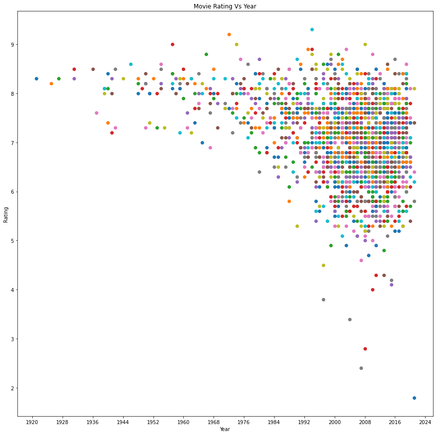

```python
cdf.sort_values(by=["startYear"], inplace=True)

f1 = plt.figure()
f1.set_figheight(15)
f1.set_figwidth(15)
sub1 = f1.add_subplot()

# Here we are iterating over cdf and plotting each row as a point.
for i, r in cdf.iterrows():
    sub1.scatter(r["startYear"], r["averageRating"])

sub1.xaxis.set_major_locator(plt.MaxNLocator(15))
sub1.set_xlabel("Year")
sub1.set_ylabel("Rating")
sub1.set_title("Movie Rating Vs Year")

f1.add_subplot(sub1)
f1.show()
```

This is certainly interesting. Over time, there have been more and more movies with over 100,000 votes with wider distributions of scores. Maybe we can find a way to represent this data in a way that gives us a bit more information in the next section.

Next, let's see how prevalent different genres are among the most popular movies. First, we need to make a list of the different genres that appear.

```python
flatList = [ item for elem in cdf["genres"] for item in elem ]

unique_genres = []
for i in flatList:
    if i not in unique_genres:
        unique_genres.append(i)

print(unique_genres)
```

```
['Comedy', 'Drama', 'Family', 'Adventure', 'Sci-Fi', 'Romance', 'Crime', 'Mystery', 'Thriller', 'Animation', 'Fantasy', 'History', 'War', 'Film-Noir', 'Western', 'Musical', 'Action', 'Music', 'Biography', 'Horror', 'Sport', 'Documentary']
```

Now that we have a unique list of the genres, we can create a dictionary that will track the prevalence of each of the genres as we iterate over the cdf and count them.

[output not shown]

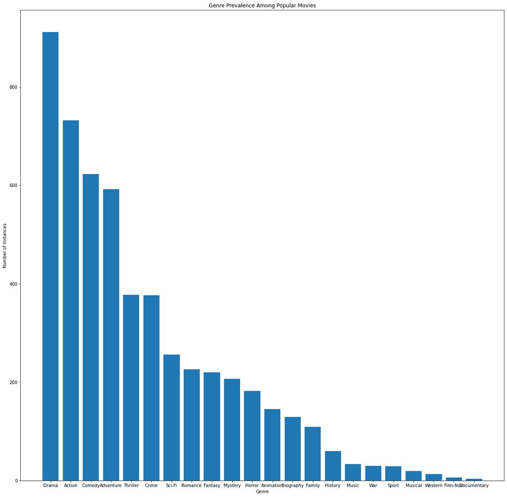

```python
genres = {
    'Comedy': 0,
    'Drama': 0,
    'Family': 0,
    'Adventure': 0,
    'Sci-Fi': 0,
    'Romance': 0,
    'Crime': 0,
    'Mystery': 0,
    'Thriller': 0,
    'Animation': 0,
    'Fantasy': 0,
    'History': 0,
    'War': 0,
    'Film-Noir': 0,
    'Western': 0,
    'Musical': 0,
    'Action': 0,
    'Music': 0,
    'Biography': 0,
    'Horror': 0,
    'Sport': 0,
    'Documentary': 0
}

for i, r in cdf.iterrows():
    for j in r["genres"]:
        genres[j] = genres[j]+1

print(genres)

genres = dict(sorted(genres.items(), key=lambda x:x[1], reverse=True))

f2 = plt.figure()
f2.set_figwidth(20)
f2.set_figheight(20)

plt.bar(range(len(genres)), list(genres.values()), align='center')
plt.xticks(range(len(genres)), list(genres.keys()))
plt.xlabel("Genre")
plt.ylabel("Number of Instances")
plt.title("Genre Prevalence Among Popular Movies")
plt.show()
```

The data shows that drama movies are by far the most popular movies in our set, followed by action, comedy, and adventure, then falling off after that; this is certainly interesting to see, but may not be relevant for the data analysis we will be doing.

## Hypothesis Testing

One complaint that I've heard a lot growing up from older generations is that they don't "make 'em like they used to." This can be in reference to a lot of things, but at least where I grew up was ultimately a product of a sense of "cultural degradation," which is a primarily white supremacist/colonialist mindset that "culture" (read: colonial/fascist ideals of assimilation and erasure of minority peoples and cultures) is being degraded by the other (non-white people, queer people, trans people, neurodivergent/disabled people, etc). (Note: There's an excellent video essay by Youtuber Jacob Geller deconstructing similar ideas in relation to modern art available at https://www.youtube.com/watch?v=v5DqmTtCPiQ for those interested. Content warning for discussion of sensitive topics.)

Is this way of thinking a product of nostalgia combined with backlash at the social progress of the last century, or are movies actually getting worse?

Let's see if there are any trends among the distribution of movies across time by applying a trend line. At first glance, the distribution looks curved, so let's try a square fit.

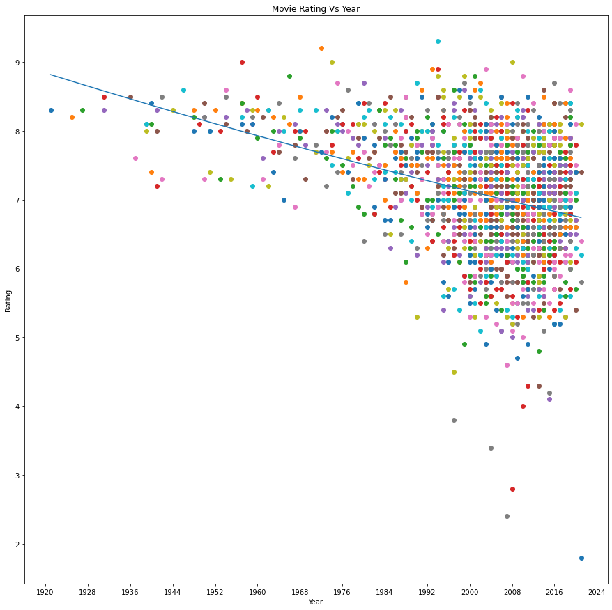

```python
a = np.polyfit(cdf.startYear, cdf.averageRating, 2)

f3 = plt.figure()
f3.set_figheight(15)
f3.set_figwidth(15)
sub3 = f3.add_subplot()

for i, r in cdf.iterrows():
    sub3.scatter(r["startYear"], r["averageRating"])

sub3.plot(cdf.startYear, a[0]*cdf.startYear*cdf.startYear+a[1]*cdf.startYear+a[2])

sub3.xaxis.set_major_locator(plt.MaxNLocator(15))
sub3.set_xlabel("Year")
sub3.set_ylabel("Rating")
sub3.set_title("Movie Rating Vs Year")

f3.add_subplot(sub3)
f3.show()
```

Interesting. The square fit gives a line that's pretty much linear, which was not expected. It is also on a significant downward trend. Does this mean that movies are progressively getting worse, as many people would like you to believe? Let's see if we can account for some things.

First, let's iterate over time and count how many movies are in the system from that year or before, sort of like a cumulative distribution function except not normalized. Additionally, I am going to plot the year IMDb was created (1990) and the year it was moved to the web (1993), for reasons that will become clear later.

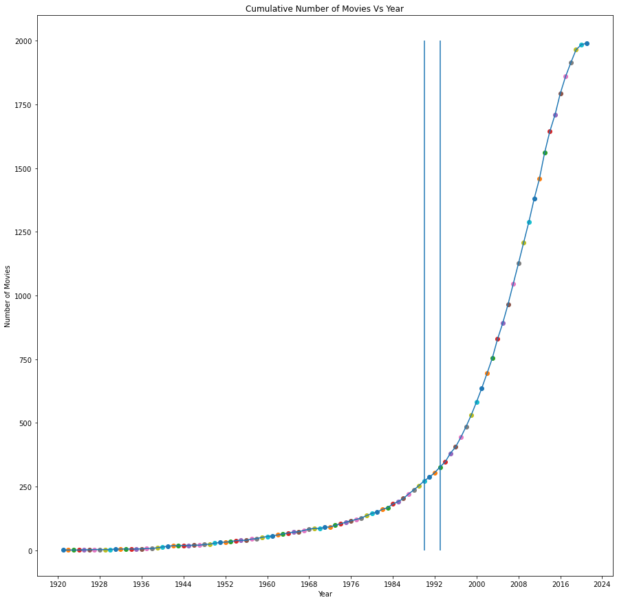

```python
f4 = plt.figure()
f4.set_figheight(15)
f4.set_figwidth(15)
sub4 = f4.add_subplot()

cumulative_dist = []

for i in range(101):
    cumulative_dist.append(cdf[cdf.startYear <= 1921+i].shape[0])
    sub4.scatter(1921+i, cumulative_dist[i])

sub4.plot(range(1921,2022), cumulative_dist)
plt.vlines([1990, 1993], 0, 2000)

sub4.xaxis.set_major_locator(plt.MaxNLocator(15))
sub4.set_xlabel("Year")
sub4.set_ylabel("Number of Movies")
sub4.set_title("Cumulative Number of Movies Vs Year")

f4.add_subplot(sub4)
f4.show()
```

The inflection over the last 2 years (2020 & 2021) should be disregarded as outliers due to the ongoing pandemic and the resultant mass delays and cancellations of new movies.

## Conclusions

Now, there are very likely other factors playing into the structure of the data, such as potentially increasing markets for movies or higher volumes of movies being created. However, even with our admittedly limited perspective, there are very clearly two distinct periods of the database, with the inflection point of the graph coinciding with the creation of IMDb. Prior to the creation of IMDb, there are very few movies with over 100,000 ratings. However, after the creation and popularization of IMDb, the amount of movies with over 100,000 ratings explodes.

It is unfortunately unable to be tested in in this instance, as my personal computer does not have the hardware to run comprehensive analysis on a quarter of a million movies, but my personal theory regarding this is that movies that came out before the creation of the database have a substantially decreased amount of ratings and documentation compared to movies that came out after. It makes sense if you think about it; very few people are going to, upon hearing about the database, go through and rank every movie they've ever seen before the database was created. Rather, once the database was created, people would likely go to rank movies after they've seen them. This means that only the best movies from before the creation of the database - ones that people continually rewatch or think about - will get ranked, leading to the inflated average rating for older popular movies. Additionally on a pure quantity scale, the popularization of streaming services and increased internet and television access means that overall, it's also likely that more movies are being watched by more people. It's not that movies are getting worse, it's just that movies in general are getting critically analyized and categorized on a much larger scale, leading to the bad movies also getting a large amount of coverage and reviews.

This analysis is evidence that the most important aspect of data science is context. It is extremely easy to either manipulate data to fit one's viewpoint or make a false claim based on bad analysis. At all times, remember your confines. The set we worked with today was extremely narrow, due both to hardware limitations as well as the limitations of creating, maintaining, and updating a crowdsourced database off of popularity. We had to do a massive amount of filtering, as it's not exactly objective or ethical to say that an episode of a little-known tv show that a single person voted a 10.0 is better than The Shawshank Redemption with a score of 9.3 across 2.5 million votes. The limitations of your data and the methods by which that data was obtained are as important as the data they show, if not more so. If there's one tenet you come away with from this tutorial, it should be this.